# lab 7.8.1 Overview

Xiaobai Guo,Nate Atkins, Cody Clark

### Objectives

1. Explore non-linear models as a more practical way of solving real-world problems
2. Gain exposure to polynomial regression and step-functions
3. Explore the `Wage` dataset and within it, the relationship between `age` and `wage`

### Dataset

The `Wage` dataset contains real wage and other data for a group of 3000 male workers in the Mid-Atlantic region in from 2003-2009. Here we will be exploring `age` as our X and `wage` as our Y.

```r
library(ISLR)
summary(Wage)
```

```
##       year           age                     maritl           race
##  Min.   :2003   Min.   :18.00   1. Never Married: 648   1. White:2480
##  1st Qu.:2004   1st Qu.:33.75   2. Married      :2074   2. Black: 293
##  Median :2006   Median :42.00   3. Widowed      :  19   3. Asian: 190
##  Mean   :2006   Mean   :42.41   4. Divorced     : 204   4. Other:  37
##  3rd Qu.:2008   3rd Qu.:51.00   5. Separated    :  55
##  Max.   :2009   Max.   :80.00
##
##               education                     region
##  1. < HS Grad      :268   2. Middle Atlantic   :3000
##  2. HS Grad        :971   1. New England       :   0
##  3. Some College   :650   3. East North Central:   0
##  4. College Grad   :685   4. West North Central:   0
##  5. Advanced Degree:426   5. South Atlantic    :   0
##                           6. East South Central:   0
##                           (Other)              :   0
##            jobclass               health      health_ins      logwage
##  1. Industrial :1544   1. <=Good     : 858   1. Yes:2083   Min.   :3.000
##  2. Information:1456   2. >=Very Good:2142   2. No : 917   1st Qu.:4.447
##                                                            Median :4.653
##                                                            Mean   :4.654
##                                                            3rd Qu.:4.857
##                                                            Max.   :5.763
##
##       wage
##  Min.   : 20.09
##  1st Qu.: 85.38
##  Median :104.92
##  Mean   :111.70
##  3rd Qu.:128.68
##  Max.   :318.34
##
```

First, we fit the model using the `lm()` function, the `poly()` command just allows us to avoid a long formula with powers of age. The function returns an orthogonal polynomials, which is a linear combination of the variable.

```r
attach(Wage)
fit=lm(wage~poly(age ,4) ,data=Wage)
coef(summary (fit))
```

```
##                 Estimate Std. Error    t value     Pr(>|t|)
## (Intercept)    111.70361  0.7287409 153.283015 0.000000e+00
## poly(age, 4)1  447.06785 39.9147851  11.200558 1.484604e-28
## poly(age, 4)2 -478.31581 39.9147851 -11.983424 2.355831e-32
## poly(age, 4)3  125.52169 39.9147851   3.144742 1.678622e-03
## poly(age, 4)4  -77.91118 39.9147851  -1.951938 5.103865e-02
```

We can also use `poly()` to obtain variables directly by using `raw=TRUE`, and it does affects the coefficient, but not the fitted values.

```r
fit2=lm(wage~poly(age ,4,raw=T),data=Wage)
coef(summary(fit2))
```

```
##                             Estimate   Std. Error   t value     Pr(>|t|)
## (Intercept)            -1.841542e+02 6.004038e+01 -3.067172 0.0021802539
## poly(age, 4, raw = T)1  2.124552e+01 5.886748e+00  3.609042 0.0003123618
## poly(age, 4, raw = T)2 -5.638593e-01 2.061083e-01 -2.735743 0.0062606446
## poly(age, 4, raw = T)3  6.810688e-03 3.065931e-03  2.221409 0.0263977518
## poly(age, 4, raw = T)4 -3.203830e-05 1.641359e-05 -1.951938 0.0510386498
```

There are other ways to fit the model. one way to do is that by using the wrapper function `I()` to protect terms like age^2

```r
fit2a=lm(wage~age+I(age^2)+I(age^3)+I(age^4),data=Wage)
coef(fit2a)
```

```
##   (Intercept)           age      I(age^2)      I(age^3)      I(age^4)
## -1.841542e+02  2.124552e+01 -5.638593e-01  6.810688e-03 -3.203830e-05
```

We can also use `cbind()` function for building a matrix from a collection of vectors.

```r
fit2b=lm(wage~cbind(age ,age^2,age^3, age ^4),data=Wage)
coef(fit2b)
```

```
##                        (Intercept) cbind(age, age^2, age^3, age^4)age
##                      -1.841542e+02                       2.124552e+01
##    cbind(age, age^2, age^3, age^4)    cbind(age, age^2, age^3, age^4)
##                      -5.638593e-01                       6.810688e-03
##    cbind(age, age^2, age^3, age^4)
##                      -3.203830e-05
```

```r
agelims=range(age)
age.grid=seq(from=agelims[1],to=agelims[2])
preds=predict(fit,newdata=list(age=age.grid),se=TRUE)
se.bands=cbind(preds$fit+2*preds$se.fit,preds$fit-2*preds$se.fit)
```

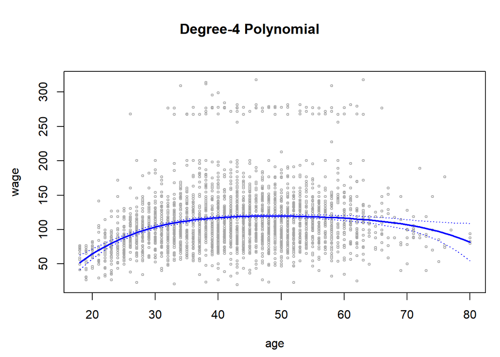

```r
par(mfrow=c(1,1),mar=c(4.5,4.5,1,1),oma=c(0,0,4,0))
plot(age,wage,xlim=agelims,cex=.5,col="darkgrey")
title("Degree-4 Polynomial",outer=T)
lines(age.grid,preds$fit,lwd=2,col="blue")
matlines(age.grid,se.bands,lwd=1,col="blue",lty=3)
```

Whether or not an orthogonal set of basis function is produced by the `poly()` function will not affect the model. The fitted values are identical.

The following expression shows that the biggest difference in fit between the two models is effectively zero:

```r
preds2=predict(fit2,newdata=list(age=age.grid),se=TRUE)
max(abs(preds$fit-preds2$fit))
```

```
## [1] 7.81597e-11
```

### Choosing a “Best” Model

First, we must decide what degree polynomial to use. Hypothesis testing is one way to do this. We use the `anova()` function to compare the five models and test for the following hypotheses:

Null: The initial, simple model (M1) is sufficient to explain the model

Alternative: A more complex model (M2) is required

Note: M1’s features must be a subset of M2’s (nested models).

```r
fit.1=lm(wage~age,data=Wage)
fit.2=lm(wage~poly(age,2),data=Wage)
fit.3=lm(wage~poly(age,3),data=Wage)
fit.4=lm(wage~poly(age,4),data=Wage)
fit.5=lm(wage~poly(age,5),data=Wage)
anova(fit.1,fit.2,fit.3,fit.4,fit.5)
```

```
## Analysis of Variance Table
##
## Model 1: wage ~ age
## Model 2: wage ~ poly(age, 2)
## Model 3: wage ~ poly(age, 3)
## Model 4: wage ~ poly(age, 4)
## Model 5: wage ~ poly(age, 5)
##   Res.Df     RSS Df Sum of Sq        F    Pr(>F)
## 1   2998 5022216
## 2   2997 4793430  1    228786 143.5931 < 2.2e-16 ***
## 3   2996 4777674  1     15756   9.8888  0.001679 **
## 4   2995 4771604  1      6070   3.8098  0.051046 .
## 5   2994 4770322  1      1283   0.8050  0.369682
## ---
## Signif. codes:  0 '***' 0.001 '**' 0.01 '*' 0.05 '.' 0.1 ' ' 1
```

Comparing the p-values shows us that either a degree 3 or 4 polynomial appears to offer the best fit for the model. The p-values can be obtained more easily as follows:

```r
coef(summary(fit.5))
```

```
##                 Estimate Std. Error     t value     Pr(>|t|)
## (Intercept)    111.70361  0.7287647 153.2780243 0.000000e+00
## poly(age, 5)1  447.06785 39.9160847  11.2001930 1.491111e-28
## poly(age, 5)2 -478.31581 39.9160847 -11.9830341 2.367734e-32
## poly(age, 5)3  125.52169 39.9160847   3.1446392 1.679213e-03
## poly(age, 5)4  -77.91118 39.9160847  -1.9518743 5.104623e-02
## poly(age, 5)5  -35.81289 39.9160847  -0.8972045 3.696820e-01
```

The p-values are the same, and the t-statistics are the square roots of the F-statistics obtained via the `anova()` function.

```r
(-11.983)^2
```

```
## [1] 143.5923
```

The `anova()` function is convenient because it works whether or not the polynomials it compares are orthogonal. Here is an example which uses `anova()` to compare models with multiple other terms.

```r
fit.1=lm(wage~education+age,data=Wage)
fit.2=lm(wage~education+poly(age,2),data=Wage)
fit.3=lm(wage~education+poly(age,3),data=Wage)
anova(fit.1,fit.2,fit.3)
```

```
## Analysis of Variance Table
##
## Model 1: wage ~ education + age
## Model 2: wage ~ education + poly(age, 2)
## Model 3: wage ~ education + poly(age, 3)
##   Res.Df     RSS Df Sum of Sq        F Pr(>F)
## 1   2994 3867992
## 2   2993 3725395  1    142597 114.6969 <2e-16 ***
## 3   2992 3719809  1      5587   4.4936 0.0341 *
## ---
## Signif. codes:  0 '***' 0.001 '**' 0.01 '*' 0.05 '.' 0.1 ' ' 1
```

### Polynomial Logistic Regression

In this instance the topic of interest is whether or not the polynomials of age can predict whether an individual earns more than $250,000 per year.

We fit a logistic regression model to a binary response variable utilzing the wrapper `(I)` function below. This expression `(I(wage>250))` evaluates to a logical variable containing `TRUEs` and `FALSEs`, which `glm()` coerces into binary by setting the `TRUEs` to 1 and `FALSEs` to 0.

```r
fit=glm(I(wage>250)~poly(age,4),data=Wage,family=binomial)
summary(fit)
```

```
##
## Call:
## glm(formula = I(wage > 250) ~ poly(age, 4), family = binomial,
##     data = Wage)
##
## Deviance Residuals:
##     Min       1Q   Median       3Q      Max
## -0.3110  -0.2607  -0.2488  -0.1791   3.7859
##
## Coefficients:
##               Estimate Std. Error z value Pr(>|z|)
## (Intercept)    -4.3012     0.3451 -12.465  < 2e-16 ***
## poly(age, 4)1  71.9642    26.1176   2.755  0.00586 **
## poly(age, 4)2 -85.7729    35.9043  -2.389  0.01690 *
## poly(age, 4)3  34.1626    19.6890   1.735  0.08272 .
## poly(age, 4)4 -47.4008    24.0909  -1.968  0.04912 *
## ---
## Signif. codes:  0 '***' 0.001 '**' 0.01 '*' 0.05 '.' 0.1 ' ' 1
##
## (Dispersion parameter for binomial family taken to be 1)
##
##     Null deviance: 730.53  on 2999  degrees of freedom
## Residual deviance: 701.22  on 2995  degrees of freedom
## AIC: 711.22
##
## Number of Fisher Scoring iterations: 9
```

Utilize the predict function to make predictions of the polynomial logistic regression model. The default prediction type for a `glm()` model is `type="link"`, which means we calculate predictions for the logit (log-odds) rather than probabilities.

```r
preds=predict(fit,newdata=list(age=age.grid),se=T)
```

Calculating confidence intervals and standard error bands. Since the computations are logit we will need to apply inverse logit mapping.

```r
pfit = exp(preds$fit) / (1+exp(preds$fit))
se.bands.logit = cbind(lower=preds$fit-2*preds$se.fit,upper=preds$fit+2*preds$se.fit)
se.bands = exp(se.bands.logit)/(1+exp(se.bands.logit))
tail(se.bands)
```

```
##           lower     upper
## 58 1.271472e-07 0.3445818
## 59 1.038022e-08 0.4103453
## 60 6.073219e-10 0.4852140
## 61 2.481151e-11 0.5665793
## 62 6.889563e-13 0.6500903
## 63 1.264430e-14 0.7303159
```

This is an example of how a `type="response"` prediction should be set up, however, it is yielding negative probabilities and should not be used!

```r
pred.p=predict(fit,newdata=list(age=age.grid),type="response",se=T)
```

### Graph The Data

Below is the code and plot associated with predicted fit and standard error bands. Observed wage values greater than 250K are shown as gray marks at the top of the plot while observations of wage values less than 250K are shown as gray marks at the bottom of the plot.

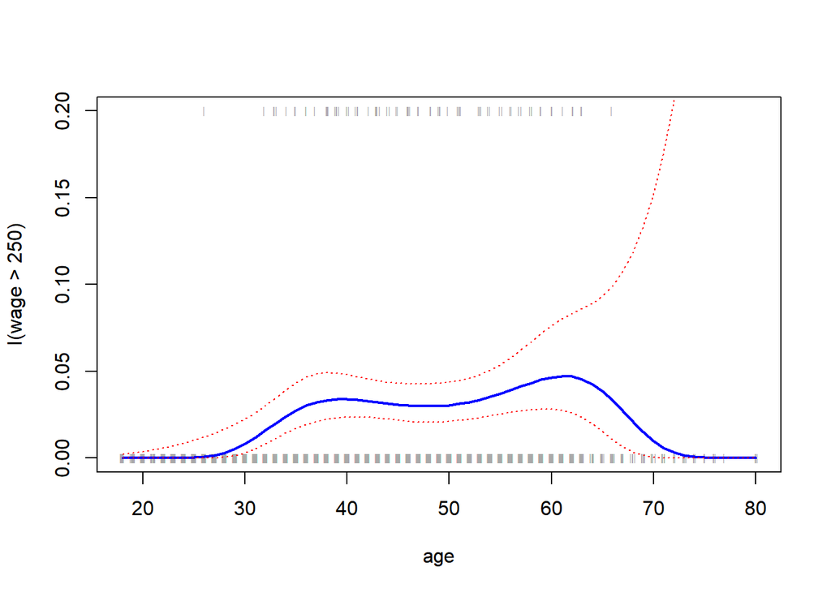

```r
plot(age,I(wage>250),xlim=agelims,type="n",ylim=c(0,.2))
points(jitter(age), I((wage>250)/5),cex=.5,pch="|",col="darkgrey")
lines(age.grid,pfit,lwd=2, col="blue")
matlines(age.grid,se.bands,lwd=1,col="red",lty=3)
```

`Jitter()` function is used so age observations with the same value do not cover each other.

This plot is sometimes referred to as a rug plot.

### Step Function

In this exercise we utilize the cut function to break the age variable into 4 segments and then build a linear model according to the segments.

```r
table(cut(age,4))
```

```
##
## (17.9,33.5]   (33.5,49]   (49,64.5] (64.5,80.1]
##         750        1399         779          72
```

```r
fit=lm(wage~cut(age,4),data=Wage)
coef(summary(fit))
```

```
##                         Estimate Std. Error   t value     Pr(>|t|)
## (Intercept)            94.158392   1.476069 63.789970 0.000000e+00
## cut(age, 4)(33.5,49]   24.053491   1.829431 13.148074 1.982315e-38
## cut(age, 4)(49,64.5]   23.664559   2.067958 11.443444 1.040750e-29
## cut(age, 4)(64.5,80.1]  7.640592   4.987424  1.531972 1.256350e-01
```

The “cut()” function returns an ordered categorical variable; the “lm()” function then creates a set of dummy variables for use in the regression. The age<33.5 category is left out, so the intercept coefficient of $94,160 can be interpreted as the average salary for those under 33.5 years of age, and the other coefficients can be interpreted as the average additional salary for those in the other age groups.